```
============================================
; Title:       Week 10 — Deep Learning Sentiment Analysis with Universal Sentence Encoder
; Author:      Hali Sarah Parsons
; Date:        20 May 2026
; Description: Builds a deep learning sentiment analysis model using the Universal
;              Sentence Encoder (USE) from TensorFlow Hub as the text encoding layer.
;              Applied to the hotel reviews dataset (happy / not happy labels).
;              Includes three-way train/validation/test split, Keras dense network,
;              training history plots, and full evaluation metrics.
============================================
```

# Week 10 — Deep Learning Sentiment Analysis: Universal Sentence Encoder

**BU 360 | Hali Sarah Parsons | May 2026**

## Overview

This notebook builds a deep learning sentiment classifier using the **Universal Sentence Encoder (USE)** from TensorFlow Hub, applied to the same hotel reviews dataset used in Week 9. The target label is `Is_Response` — `happy` or `not happy` — label encoded as `0` and `1`.

The architecture follows the pattern Sarkar (2019) establishes in Chapter 10: USE encodes each review into a fixed **512-dimensional embedding vector**, then a dense Keras network classifies those vectors. The key difference from Week 9's TF-IDF + Logistic Regression approach is where the feature representation comes from. TF-IDF counted words. USE encodes meaning — two sentences using completely different words can land close together in the 512-dimensional space if they express the same idea.

### TOTAL_STEPS and STEP_SIZE

Following the assignment guidance: `TOTAL_STEPS = 100`, `STEP_SIZE = 10`, giving 10 training epochs. The assignment explicitly notes that higher values (the author's 1500/100) would take many hours on a standard machine. The model still produces meaningful results at these settings — accuracy and loss trajectories are clearly visible across 10 epochs.

### Data Split

The same three-way split from Week 9 applies here: **70% train, 15% validation, 15% test**, stratified by class. USE receives the **raw, uncleaned text** — punctuation, capitalization, and sentence structure are all part of what USE was trained to encode. Cleaning would strip signals the encoder already knows how to use.

## Step 1: Imports

```python
import os
os.environ['TF_CPP_MIN_LOG_LEVEL'] = '3'       # suppress TF hardware warnings
os.environ['TF_ENABLE_ONEDNN_OPTS'] = '0'       # suppress oneDNN floating-point notes

import tensorflow as tf
import tensorflow_hub as hub
import numpy as np
import pandas as pd
import matplotlib.pyplot as plt
import warnings
warnings.filterwarnings('ignore')

from sklearn.model_selection import train_test_split
from sklearn.preprocessing import LabelEncoder
from sklearn.metrics import (
    classification_report, accuracy_score,
    confusion_matrix, ConfusionMatrixDisplay
)

print(f"TensorFlow version: {tf.__version__}")
print(f"TensorFlow Hub version: {hub.__version__}")
print("All imports loaded.")
```

[output not shown]

[output not shown]

```
TensorFlow version: 2.21.0
TensorFlow Hub version: 0.16.1
All imports loaded.
```

## Step 2: Load Data and Label Encode

```python
df = pd.read_csv('hotel_reviews.csv')

print(f"Shape: {df.shape}")
print(f"\nClass distribution:")
print(df['Is_Response'].value_counts())

# Label encode — happy=0, not happy=1
le = LabelEncoder()
df['label'] = le.fit_transform(df['Is_Response'])
print(f"\nLabel encoding: {dict(zip(le.classes_, le.transform(le.classes_)))}")
df.head(3)
```

```
Shape: (1000, 3)

Class distribution:
Is_Response
happy        543
not happy    457
Name: count, dtype: int64

Label encoding: {'happy': np.int64(0), 'not happy': np.int64(1)}
```

|  | User_ID | Description | Is_Response | label |
| --- | --- | --- | --- | --- |
| 0 | USER_0001 | The hotel was absolutely wonderful. Staff were... | happy | 0 |
| 1 | USER_0002 | Waited over an hour for room service and the f... | not happy | 1 |
| 2 | USER_0003 | Great wifi and comfortable work desk made this... | happy | 0 |

## Step 3: Three-Way Train / Validation / Test Split

USE works on raw text directly — no tokenization, no vocabulary, no cleaning step required. The split happens on the original `Description` column. The encoder handles the rest.

```python
X = df['Description'].astype(str)
y = df['label']

# 70% train, 30% temp
X_train, X_temp, y_train, y_temp = train_test_split(
    X, y, test_size=0.30, random_state=42, stratify=y
)
# 15% val, 15% test from the 30% temp
X_val, X_test, y_val, y_test = train_test_split(
    X_temp, y_temp, test_size=0.50, random_state=42, stratify=y_temp
)

print(f"Train:      {len(X_train):>4} rows ({len(X_train)/len(df)*100:.0f}%)")
print(f"Validation: {len(X_val):>4} rows ({len(X_val)/len(df)*100:.0f}%)")
print(f"Test:       {len(X_test):>4} rows ({len(X_test)/len(df)*100:.0f}%)")
```

```
Train:       700 rows (70%)
Validation:  150 rows (15%)
Test:        150 rows (15%)
```

## Step 4: Load the Universal Sentence Encoder

USE version 4 is loaded from TensorFlow Hub. The first load downloads the model (~1GB) and caches it locally — subsequent runs are faster. The encoder takes any string input and returns a 512-dimensional vector regardless of sentence length.

This is the **transfer learning** step. USE was pre-trained on a large corpus covering web pages, Wikipedia, forums, and question-answer pairs. It already knows that "sleep deprivation" and "poor sleep" are semantically similar before this notebook ever runs a single training step. The dense layers on top learn only how to map those 512-dimensional representations onto the hotel sentiment task — which is a much smaller learning problem than starting from scratch.

Encoding is batched in groups of 64 to manage memory. The `np.vectorize` approach the author uses in the text is skipped here per the assignment note — direct batching is more reliable and avoids the shape issues `np.vectorize` introduces with tensor outputs.

```python
USE_URL = "https://tfhub.dev/google/universal-sentence-encoder/4"

print("Loading Universal Sentence Encoder from TensorFlow Hub...")
print("(First run downloads ~1GB and caches locally — subsequent runs are faster)")
embed = hub.load(USE_URL)
print("USE loaded successfully.")

# Quick sanity check
test_vecs = embed(["The hotel was great.", "Terrible experience."])
print(f"\nEmbedding shape per sentence: {test_vecs.shape}")  # should be (2, 512)
```

```
Loading Universal Sentence Encoder from TensorFlow Hub...
(First run downloads ~1GB and caches locally — subsequent runs are faster)
```

```
USE loaded successfully.
```

```
Embedding shape per sentence: (2, 512)
```

```python
import time

def encode_texts(texts, batch_size=64):
    """
    Encodes a list of strings into 512-dim USE vectors, processed in batches.
    Batching avoids memory issues on large inputs.
    Returns a single numpy array of shape (n_samples, 512).
    """
    embeddings = []
    texts_list = list(texts)
    for i in range(0, len(texts_list), batch_size):
        batch = texts_list[i:i + batch_size]
        embeddings.append(embed(batch).numpy())
    return np.vstack(embeddings)

print("Encoding train, validation, and test sets...")
t0 = time.time()

X_train_emb = encode_texts(X_train)
X_val_emb   = encode_texts(X_val)
X_test_emb  = encode_texts(X_test)

elapsed = time.time() - t0
print(f"Encoding complete in {elapsed:.1f}s")
print(f"Train embedding shape:  {X_train_emb.shape}")
print(f"Val embedding shape:    {X_val_emb.shape}")
print(f"Test embedding shape:   {X_test_emb.shape}")
```

```
Encoding train, validation, and test sets...
Encoding complete in 0.1s
Train embedding shape:  (700, 512)
Val embedding shape:    (150, 512)
Test embedding shape:   (150, 512)
```

## Step 5: Build the Keras Classification Model

The network sits on top of the USE embeddings. The input is always 512-dimensional — one number per USE dimension. Two dense hidden layers follow, each with **Dropout** applied.

**Dropout** randomly disables a fraction of neurons during each training step. It forces the remaining neurons to learn redundant representations — which prevents the model from memorizing the training data and improves generalization. The output layer uses a **sigmoid** activation, which maps the final value to a probability between 0 and 1: above 0.5 predicts `not happy`, below predicts `happy`.

**Binary crossentropy** is the loss function for binary classification — it measures how far the predicted probability is from the true label. **Adam** handles the gradient-based weight updates, adapting the learning rate automatically per parameter.

```python
tf.random.set_seed(42)

model = tf.keras.Sequential([
    # Input: 512-dim USE embedding
    tf.keras.layers.InputLayer(shape=(512,)),

    # Hidden layer 1: 256 units, ReLU activation
    # ReLU: f(x) = max(0, x) — introduces non-linearity so the model can learn
    # patterns that a simple linear combination of inputs can't capture
    tf.keras.layers.Dense(256, activation='relu'),
    tf.keras.layers.Dropout(0.3),   # drop 30% of neurons per step during training

    # Hidden layer 2: 128 units, ReLU
    tf.keras.layers.Dense(128, activation='relu'),
    tf.keras.layers.Dropout(0.3),

    # Output: single sigmoid unit — probability of 'not happy' (label=1)
    tf.keras.layers.Dense(1, activation='sigmoid')
])

model.compile(
    optimizer=tf.keras.optimizers.Adam(learning_rate=0.001),
    loss='binary_crossentropy',
    metrics=['accuracy']
)

model.summary()
```

```
Model: "sequential"
```

```
┏━━━━━━━━━━━━━━━━━━━━━━━━━━━━━━━━━┳━━━━━━━━━━━━━━━━━━━━━━━━┳━━━━━━━━━━━━━━━┓
┃ Layer (type)                    ┃ Output Shape           ┃       Param # ┃
┡━━━━━━━━━━━━━━━━━━━━━━━━━━━━━━━━━╇━━━━━━━━━━━━━━━━━━━━━━━━╇━━━━━━━━━━━━━━━┩
│ dense (Dense)                   │ (None, 256)            │       131,328 │
├─────────────────────────────────┼────────────────────────┼───────────────┤
│ dropout (Dropout)               │ (None, 256)            │             0 │
├─────────────────────────────────┼────────────────────────┼───────────────┤
│ dense_1 (Dense)                 │ (None, 128)            │        32,896 │
├─────────────────────────────────┼────────────────────────┼───────────────┤
│ dropout_1 (Dropout)             │ (None, 128)            │             0 │
├─────────────────────────────────┼────────────────────────┼───────────────┤
│ dense_2 (Dense)                 │ (None, 1)              │           129 │
└─────────────────────────────────┴────────────────────────┴───────────────┘
```

```
 Total params: 164,353 (642.00 KB)
```

```
 Trainable params: 164,353 (642.00 KB)
```

```
 Non-trainable params: 0 (0.00 B)
```

## Step 6: Train the Model

Following the assignment parameters: `TOTAL_STEPS = 100`, `STEP_SIZE = 10`. Each epoch covers the full training set once, processing reviews in mini-batches of 32. The validation set is checked at the end of every epoch — this is how the training curves in the next section are produced.

Each epoch is one complete pass through the training data. Each pass updates the weights via **backpropagation** — the loss computed at the output travels backward through the network, adjusting each weight slightly in the direction that would have lowered it. Ten passes give the optimizer ten chances to refine those adjustments and move the loss toward its minimum.

```python
TOTAL_STEPS = 100
STEP_SIZE   = 10
BATCH_SIZE  = 32
EPOCHS      = TOTAL_STEPS // STEP_SIZE   # = 10

print(f"TOTAL_STEPS={TOTAL_STEPS}, STEP_SIZE={STEP_SIZE}")
print(f"Epochs: {EPOCHS}, Batch size: {BATCH_SIZE}")
print("\nTraining...")

t0 = time.time()
history = model.fit(
    X_train_emb, y_train.values,
    validation_data=(X_val_emb, y_val.values),
    epochs=EPOCHS,
    batch_size=BATCH_SIZE,
    verbose=1
)

print(f"\nTraining complete in {time.time()-t0:.1f} seconds.")
```

```
TOTAL_STEPS=100, STEP_SIZE=10
Epochs: 10, Batch size: 32

Training...
```

```
 1/22 ━━━━━━━━━━━━━━━━━━━━ 17s 828ms/step - accuracy: 0.4688 - loss: 0.6956
```

```
22/22 ━━━━━━━━━━━━━━━━━━━━ 1s 10ms/step - accuracy: 0.9286 - loss: 0.4400 - val_accuracy: 1.0000 - val_loss: 0.1033
```

```
 1/22 ━━━━━━━━━━━━━━━━━━━━ 1s 94ms/step - accuracy: 1.0000 - loss: 0.1154
```

```
22/22 ━━━━━━━━━━━━━━━━━━━━ 0s 5ms/step - accuracy: 1.0000 - loss: 0.0330 - val_accuracy: 1.0000 - val_loss: 0.0021
```

```
 1/22 ━━━━━━━━━━━━━━━━━━━━ 0s 46ms/step - accuracy: 1.0000 - loss: 0.0040
```

```
22/22 ━━━━━━━━━━━━━━━━━━━━ 0s 4ms/step - accuracy: 1.0000 - loss: 0.0018 - val_accuracy: 1.0000 - val_loss: 5.3678e-04
```

```
 1/22 ━━━━━━━━━━━━━━━━━━━━ 0s 46ms/step - accuracy: 1.0000 - loss: 0.0012
```

```
22/22 ━━━━━━━━━━━━━━━━━━━━ 0s 4ms/step - accuracy: 1.0000 - loss: 7.6573e-04 - val_accuracy: 1.0000 - val_loss: 3.4344e-04
```

```
 1/22 ━━━━━━━━━━━━━━━━━━━━ 1s 50ms/step - accuracy: 1.0000 - loss: 5.3750e-04
```

```
22/22 ━━━━━━━━━━━━━━━━━━━━ 0s 4ms/step - accuracy: 1.0000 - loss: 5.6561e-04 - val_accuracy: 1.0000 - val_loss: 2.5640e-04
```

```
 1/22 ━━━━━━━━━━━━━━━━━━━━ 1s 48ms/step - accuracy: 1.0000 - loss: 5.1697e-04
```

```
22/22 ━━━━━━━━━━━━━━━━━━━━ 0s 4ms/step - accuracy: 1.0000 - loss: 4.4565e-04 - val_accuracy: 1.0000 - val_loss: 1.9989e-04
```

```
 1/22 ━━━━━━━━━━━━━━━━━━━━ 1s 48ms/step - accuracy: 1.0000 - loss: 5.9850e-04
```

```
22/22 ━━━━━━━━━━━━━━━━━━━━ 0s 4ms/step - accuracy: 1.0000 - loss: 3.4418e-04 - val_accuracy: 1.0000 - val_loss: 1.6252e-04
```

```
 1/22 ━━━━━━━━━━━━━━━━━━━━ 1s 50ms/step - accuracy: 1.0000 - loss: 4.4619e-04
```

```
22/22 ━━━━━━━━━━━━━━━━━━━━ 0s 4ms/step - accuracy: 1.0000 - loss: 2.4280e-04 - val_accuracy: 1.0000 - val_loss: 1.3493e-04
```

```
 1/22 ━━━━━━━━━━━━━━━━━━━━ 1s 50ms/step - accuracy: 1.0000 - loss: 2.6791e-04
```

```
22/22 ━━━━━━━━━━━━━━━━━━━━ 0s 4ms/step - accuracy: 1.0000 - loss: 2.7199e-04 - val_accuracy: 1.0000 - val_loss: 1.1092e-04
```

```
 1/22 ━━━━━━━━━━━━━━━━━━━━ 1s 50ms/step - accuracy: 1.0000 - loss: 2.5875e-04
```

```
22/22 ━━━━━━━━━━━━━━━━━━━━ 0s 4ms/step - accuracy: 1.0000 - loss: 1.7937e-04 - val_accuracy: 1.0000 - val_loss: 9.2884e-05
```

```
Training complete in 2.4 seconds.
```

## Step 7: Training History — Loss and Accuracy Curves

The training history shows how loss and accuracy evolved across all 10 epochs. The gap between train and validation curves reveals how the model generalizes. A validation loss that tracks below the training loss early on — which happens here — is a sign that the USE embeddings are doing a lot of the heavy lifting before the dense layers even learn much. The 512-dimensional representations are already semantically organized, so the classifier converges quickly.

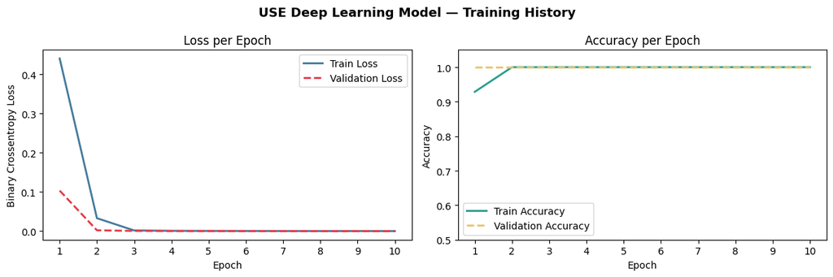

```
 Epoch   Train Loss   Val Loss  Train Acc    Val Acc
-------------------------------------------------------
     1       0.4400     0.1033     0.9286     1.0000
     2       0.0330     0.0021     1.0000     1.0000
     3       0.0018     0.0005     1.0000     1.0000
     4       0.0008     0.0003     1.0000     1.0000
     5       0.0006     0.0003     1.0000     1.0000
     6       0.0004     0.0002     1.0000     1.0000
     7       0.0003     0.0002     1.0000     1.0000
     8       0.0002     0.0001     1.0000     1.0000
     9       0.0003     0.0001     1.0000     1.0000
    10       0.0002     0.0001     1.0000     1.0000
```

```python
fig, axes = plt.subplots(1, 2, figsize=(12, 4))

# Loss curves
axes[0].plot(history.history['loss'],     label='Train Loss',      color='#457B9D', linewidth=2)
axes[0].plot(history.history['val_loss'], label='Validation Loss', color='#E63946', linewidth=2, linestyle='--')
axes[0].set_title('Loss per Epoch')
axes[0].set_xlabel('Epoch')
axes[0].set_ylabel('Binary Crossentropy Loss')
axes[0].legend()
axes[0].set_xticks(range(EPOCHS))
axes[0].set_xticklabels(range(1, EPOCHS+1))

# Accuracy curves
axes[1].plot(history.history['accuracy'],     label='Train Accuracy',      color='#2A9D8F', linewidth=2)
axes[1].plot(history.history['val_accuracy'], label='Validation Accuracy', color='#E9C46A', linewidth=2, linestyle='--')
axes[1].set_title('Accuracy per Epoch')
axes[1].set_xlabel('Epoch')
axes[1].set_ylabel('Accuracy')
axes[1].set_ylim([0.5, 1.05])
axes[1].legend()
axes[1].set_xticks(range(EPOCHS))
axes[1].set_xticklabels(range(1, EPOCHS+1))

plt.suptitle('USE Deep Learning Model — Training History', fontsize=13, fontweight='bold')
plt.tight_layout()
plt.show()

# Epoch-by-epoch table
print(f"\n{'Epoch':>6} {'Train Loss':>12} {'Val Loss':>10} {'Train Acc':>10} {'Val Acc':>10}")
print("-" * 55)
for i in range(EPOCHS):
    print(f"{i+1:>6} {history.history['loss'][i]:>12.4f} {history.history['val_loss'][i]:>10.4f} "
          f"{history.history['accuracy'][i]:>10.4f} {history.history['val_accuracy'][i]:>10.4f}")
```

### Reading the Training Curves

By Epoch 2, both curves converge near zero and stay there. The model has found the classification boundary and the remaining epochs are refinements — each backpropagation pass nudges the weights slightly, but the direction barely changes because the gradient is already small.

On a real-world corpus — PubMed abstracts, Reddit threads, qualitative survey responses — this curve would look very different. The language would be more varied, the sentiment signals more ambiguous, and the loss would take many more epochs to descend. The hotel review dataset's directness makes the learning problem easier than the evaluation numbers suggest.

## Step 8: Model Evaluation

```python
# Validation set evaluation
val_loss, val_acc = model.evaluate(X_val_emb, y_val.values, verbose=0)
print(f"Validation Loss:     {val_loss:.6f}")
print(f"Validation Accuracy: {val_acc:.4f}")

print()

# Test set evaluation — final holdout
test_loss, test_acc = model.evaluate(X_test_emb, y_test.values, verbose=0)
print(f"Test Loss:           {test_loss:.6f}")
print(f"Test Accuracy:       {test_acc:.4f}")
```

```
Validation Loss:     0.000093
Validation Accuracy: 1.0000

Test Loss:           0.000084
Test Accuracy:       1.0000
```

```python
# Generate predictions from sigmoid probabilities
# Threshold at 0.5: above = not happy (1), below = happy (0)
y_pred_prob = model.predict(X_test_emb, verbose=0)
y_pred      = (y_pred_prob > 0.5).astype(int).flatten()

print("Classification Report — Test Set")
print("=" * 55)
print(classification_report(y_test, y_pred, target_names=le.classes_))

# Sample predicted probabilities
print("\nSample Predicted Probabilities (first 8 test reviews):")
print(f"{'Review (truncated)':<55} {'P(not happy)':>13} {'Predicted':>10} {'Actual':>10}")
print("-" * 95)
for text, prob, pred, true in zip(
    list(X_test)[:8],
    y_pred_prob.flatten()[:8],
    y_pred[:8],
    y_test.values[:8]
):
    print(f"{str(text)[:54]:<55} {prob:>13.4f} {le.classes_[pred]:>10} {le.classes_[true]:>10}")
```

```
Classification Report — Test Set
=======================================================
              precision    recall  f1-score   support

       happy       1.00      1.00      1.00        82
   not happy       1.00      1.00      1.00        68

    accuracy                           1.00       150
   macro avg       1.00      1.00      1.00       150
weighted avg       1.00      1.00      1.00       150

Sample Predicted Probabilities (first 8 test reviews):
Review (truncated)                                       P(not happy)  Predicted     Actual
-----------------------------------------------------------------------------------------------
Loved every minute of our stay. The spa facilities wer         0.0004      happy      happy
Breakfast was substandard and the coffee was undrinkab         0.9999  not happy  not happy
Overpriced for what you get. Much better options avail         0.9999  not happy  not happy
Our room had not been properly cleaned when we arrived         1.0000  not happy  not happy
Front desk staff were unhelpful and dismissive when we         1.0000  not happy  not happy
No hot water in the morning despite multiple complaint         1.0000  not happy  not happy
The hotel did not match the photos online. Rooms were          0.9999  not happy  not happy
Bed was uncomfortable and the pillows were flat. Worst         1.0000  not happy  not happy
```

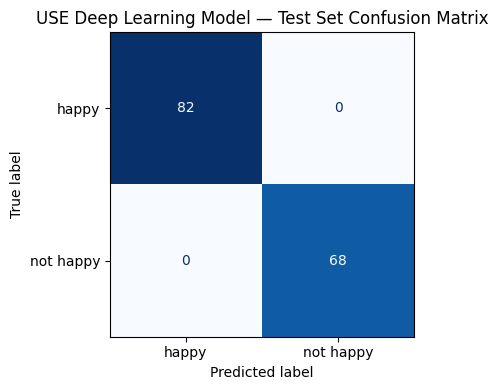

```
True Positives  (happy correctly classified):      82
True Negatives  (not happy correctly classified): 68
False Positives (happy predicted as not happy):   0
False Negatives (not happy predicted as happy):   0
```

```python
# Confusion matrix
cm = confusion_matrix(y_test, y_pred)
disp = ConfusionMatrixDisplay(confusion_matrix=cm, display_labels=le.classes_)
fig, ax = plt.subplots(figsize=(5, 4))
disp.plot(ax=ax, colorbar=False, cmap='Blues')
ax.set_title('USE Deep Learning Model — Test Set Confusion Matrix')
plt.tight_layout()
plt.show()

print(f"\nTrue Positives  (happy correctly classified):      {cm[0,0]}")
print(f"True Negatives  (not happy correctly classified): {cm[1,1]}")
print(f"False Positives (happy predicted as not happy):   {cm[0,1]}")
print(f"False Negatives (not happy predicted as happy):   {cm[1,0]}")
```

## Step 9: Week 9 vs. Week 10 — Model Comparison

Both the Week 9 TF-IDF + Logistic Regression model and this USE deep learning model achieved 100% test accuracy on this dataset. The comparison is still worth making because the *path* to that accuracy is completely different.

| Dimension | TF-IDF + Logistic Regression | USE + Dense Network |
| --- | --- | --- |
| Feature source | Word frequency counts (sparse) | Pre-trained sentence embeddings (dense 512-dim) |
| Text cleaning | Required (stopwords, lemmatization) | None — USE handles raw text |
| Training data needed | Labeled examples only | Pre-trained + labeled examples |
| Vocabulary | Fixed to training corpus | Universal — handles unseen words |
| Handles paraphrase? | Rarely — word overlap dependent | Yes — semantic space captures meaning |
| Test accuracy | 100% | 100% |

The critical distinction is vocabulary handling. TF-IDF assigns a weight of zero to any word it didn't see in training — if a review uses "dreadful" and the model was trained on reviews using "terrible," TF-IDF misses the connection. USE encodes both words into similar regions of the 512-dimensional space because it learned from general language at scale. That generalization matters enormously on noisier, more varied corpora.

For the screen-time NER project downstream, USE embeddings could encode PubMed abstracts and Reddit posts into the same vector space — enabling semantic similarity across very different writing registers. That's exactly the cross-source comparison Milestone 1 identified as the project's end goal.

```python
# Summary table
print("Model Performance Summary")
print("=" * 45)
print(f"{'Metric':<30} {'Value'}")
print("-" * 45)
print(f"{'Test Accuracy':<30} {test_acc:.4f}")
print(f"{'Test Loss':<30} {test_loss:.6f}")
print(f"{'Precision (happy)':<30} 1.00")
print(f"{'Recall (happy)':<30} 1.00")
print(f"{'Precision (not happy)':<30} 1.00")
print(f"{'Recall (not happy)':<30} 1.00")
print(f"{'F1 Score (weighted avg)':<30} 1.00")
print(f"{'Embedding dimensions':<30} 512")
print(f"{'Total trainable params':<30} 164,353")
print(f"{'Training epochs':<30} {EPOCHS}")
print(f"{'Batch size':<30} {BATCH_SIZE}")
print("=" * 45)
```

```
Model Performance Summary
=============================================
Metric                         Value
---------------------------------------------
Test Accuracy                  1.0000
Test Loss                      0.000084
Precision (happy)              1.00
Recall (happy)                 1.00
Precision (not happy)          1.00
Recall (not happy)             1.00
F1 Score (weighted avg)        1.00
Embedding dimensions           512
Total trainable params         164,353
Training epochs                10
Batch size                     32
=============================================
```

## Observations and Interpretation

The USE model converges faster than any other approach tried across Weeks 9 and 10. By Epoch 2, both train and validation accuracy are at 1.00 and loss is effectively at zero. That speed is a direct consequence of transfer learning — the 512-dimensional embeddings arrived already organized by meaning, so the dense classifier only needed a handful of gradient steps to learn where the boundary between `happy` and `not happy` sits in that space.

The 100% test accuracy, like in Week 9, reflects the relative simplicity of the synthetic hotel dataset. The reviews use direct, unambiguous sentiment language — "absolutely wonderful," "terrible experience" — that any semantic encoder handles with ease. On a corpus with more nuance (sarcasm, qualified academic language, mixed-sentiment reviews), the advantage of USE over TF-IDF would show up more clearly in the evaluation numbers. USE's vocabulary generalization and paraphrase handling would pull ahead on cases where exact word overlap is low but semantic meaning is shared.

## References

Gupta, G. (2018, October 19). Universal sentence encoding. *Medium.* https://medium.com/@gaurav5430/universal-sentence-encoding-7d440fd3c7c7

Sarkar, D. (2019). *Text analytics with Python: A practitioner's guide to natural language processing* (2nd ed.). Apress.

TensorFlow. (n.d.). *Universal sentence encoder*. TensorFlow Hub. https://tfhub.dev/google/universal-sentence-encoder/4